# Primary Feather Evolution

Angry_biRds

2022-12-15

### Introduction

Migration is an integral facet of many avian life cycles and usually leads birds from areas of low resources to areas of high resources and nesting spaces. To effectively move between distant geographic locations, migratory birds have been naturally selected for specific morphological traits, such as the length/size of wings and feathers. Most recent research has focused on the overall length of the wing and its outline in the study of the external avian morphological adaptations as it can facilitate an energy-efficient migratory flight (Hera et al. 2020). Primary feathers are a vital part of a bird’s wing and overall flight ability. These feathers are one of the most prominent features found on a bird’s wings, generating the forward thrust during flight which ultimately aids in propelling the bird into the air. If these feathers are cut or damaged, the bird’s ability to fly is significantly impaired.

### Methods

#### Image Acquisition

Images analyzed in this project were acquired through the U.S. Fish & Wildlife Service’s database: “Feather Atlas”. Avian families analyzed include Apodiformes, Colmbiformes, Galliformes, Gruiformes, & Passeriformes. Records from the Feather Atlas are accessible for all Aves further analyzed below.

#### Digitization

The outermost primary feather shapes across all species of Avians were examined utilizing the image analysis program FIJI. After opening each image in FIJI, the scale was set aligning with the scale-bar present in the database. The primary feathers were then traced utilizing the polygon selection tool. A script was created, and the selected points (x and y coordinates) were exported in a .txt file for further analysis.

#### Evolutionary Rates & Shifts

The “non-censored test” (O’Meara et al. 2006) was utilized to estimate the rates of morphological evolution over a phylogenetic tree. Phylogenetic ridge regression (Kratsch and McHardy 2014) was then utilized to determine whether the evolutionary shift was to a slower or faster rate. The regressions are based on the phenotype values at each node vs. time between nodes and along the path.

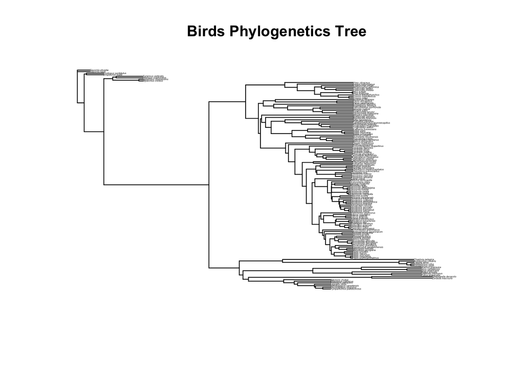

Figure 1: Modified phylogenetic tree sourced from Jetz et al. (2012). The tree was shortened to only include species analyzed in PCA.

### Results

#### Principal Components

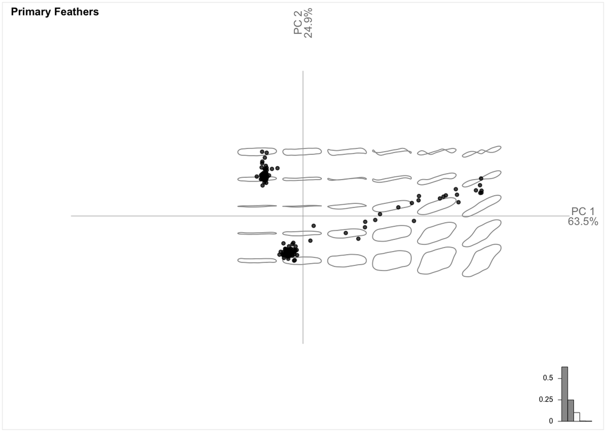

Figure 2: Biplot visualization of Principle Component 1 (PC1) and PC2 of the primary feathers.

Based on the PCA analysis results shown in figure 2, PC1, diagonal lobe thickness, and PC2, equatorial rotation, accounts for 63.5% and 24.9% of the variance in our sample respectively.

#### Evolutionary Rates: PC1 vs PC2

##### Estimated Evolutionary Rate of PC1

```
## [1] 0.006242593
```

##### Estimated Evolutionary Rate of PC2

```
## [1] 0.001396271
```

Across all observed primary feathers of various bird species, the evolutionary rate of PC1 is 0.006242593 and that of PC2 is 0.001396271, meaning PC1 is evolving at more than 4 times the rate of PC2. This could indicate there has been an elevated amount of selection pressure for PC1 in primary feathers as a potential advantageous trait in bird flight mechanics in varying environments and lifestyles when compared to other principal components.

#### Evolutionary Rate Shifts

##### PC1

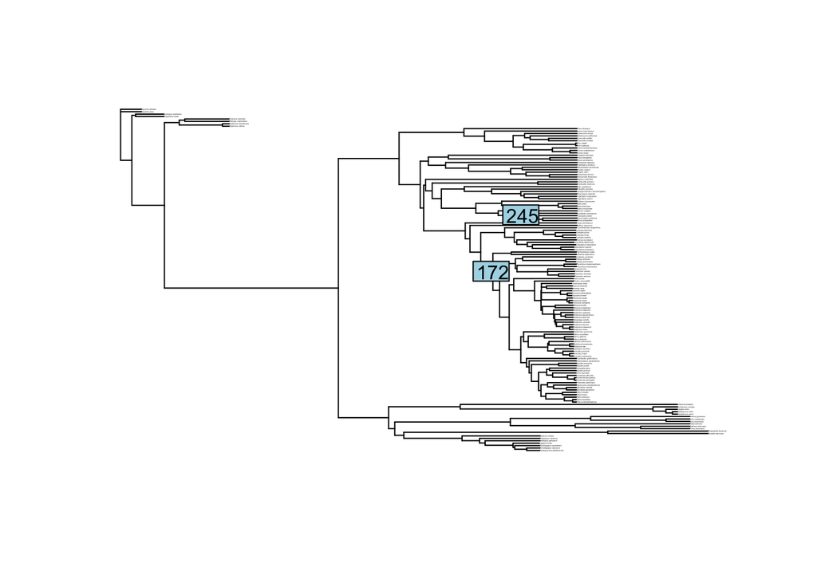

Figure 3: Evolutionary rate shift in the primary feathers’ PC1 plotted on modified phylogenetic tree. The numeric label represents at which node in the tree the shift occurred at. The table below shows the magnitude and statistical significance of the rate difference compared to the rest of the tree.

```
##     rate.difference p.value
## 172    -0.000946235   0.001
## 245     0.001148606   0.977
```

##### PC2

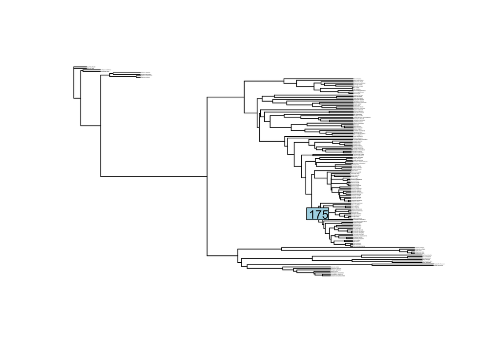

Figure 4: Evolutionary rate shift in the primary feathers’ PC2 plotted on modified phylogenetic tree. The table below shows the magnitude and statistical significance of the rate difference compared to the rest of the tree.

```
##     rate.difference p.value
## 175   -0.0003019834   0.005
```

### Discussion

To continue this study, all of the primaries of the birds should be analyzed so that the feathers’ evolutionary rate can be compared to one another. Additionally, more bird lineages should be studied to allow for a broader understanding of primary feather shape, and details about their habits (beyond migratory or nonmigratory) should be tracked to see if other factors are linked with changes in feather shape. Furthermore, previous studies have been conducted regarding the feather quality of long-distance migratory specie (Szép et al. 2019). Researchers utilized measurements of bending stiffness, feather length, and thickness to lead them to the conclusion that older individuals tend to posses better quality feathers. They also concluded that individuals who live to older ages have similar, or higher, feather growth rates than those captured at young ages. Relating to our research, utilizing known age feather samples, instead of the generalized Adult group, could provide further information regarding the adaptive significance of the traits showcased in the aforementioned study and specifically within each of the clades analyzed in our research.

### Contributions

Philip Chen (Code + Results + Data Collection)

Stephen Mooney (Code + Discussion)

Jack Kloster (Introduction + Methods + Data Collection)

Jordan Nunes (Data Collection + Discussion)

### CPK comments

Just excellent work, guys!! I’m really impressed how you conceived and executed this project. It’s an interesting question that was answered by leveraging what you learned in the class. Congrats!!! 150/150

### References

Bock, Walter J. 2015. “Explanatory History of the Origin of Feathers1.” *American Zoologist* 40 (4): 478–85. https://doi.org/10.1093/icb/40.4.478.

Hera, Iván de la, Irene Hernández-Téllez, José Pérez-Rigueiro, Javier Pérez-Tris, Francisco Javier Rojo, and José Luis Tellerı́a. 2020. “Mechanical and Structural Adaptations to Migration in the Flight Feathers of a Palaearctic Passerine.” *Journal of Evolutionary Biology* 33 (7): 979–89.

Jetz, Walter, Gavin H Thomas, Jeffery B Joy, Klaas Hartmann, and Arne O Mooers. 2012. “The Global Diversity of Birds in Space and Time.” *Nature* 491 (7424): 444–48.

Kratsch, Christina, and Alice C McHardy. 2014. “RidgeRace: Ridge Regression for Continuous Ancestral Character Estimation on Phylogenetic Trees.” *Bioinformatics* 30 (17): i527–33.

O’Meara, Brian C, Cécile Ané, Michael J Sanderson, and Peter C Wainwright. 2006. “Testing for Different Rates of Continuous Trait Evolution Using Likelihood.” *Evolution* 60 (5): 922–33.

Szép, Tibor, János Dobránszky, Anders Pape Møller, Gareth Dyke, and Ádám Z. Lendvai. 2019. “Older Birds Have Better Feathers: A Longitudinal Study on the Long-Distance Migratory Sand Martin, Riparia Riparia.” *PLOS ONE* 14 (1). https://doi.org/10.1371/journal.pone.0209737.